# Week 5 DS Recitation 1: Data Visualization

SIBDS 2023@ Columbia

28 June, 2023

## Things We Left

Here is a useful link of [ggplot cheatsheets](https://github.com/rstudio/cheatsheets/blob/main/data-visualization.pdf).

```r
# Using the weather_df as an example
weather_df =
  rnoaa::meteo_pull_monitors(
    c("USW00094728", "USC00519397", "USS0023B17S"),
    var = c("PRCP", "TMIN", "TMAX"),
    date_min = "2017-01-01",
    date_max = "2017-12-31") %>%
  mutate(
    name = recode(
      id,
      USW00094728 = "CentralPark_NY",
      USC00519397 = "Waikiki_HA",
      USS0023B17S = "Waterhole_WA"),
    tmin = tmin / 10,
    tmax = tmax / 10) %>%
  select(name, id, everything())
```

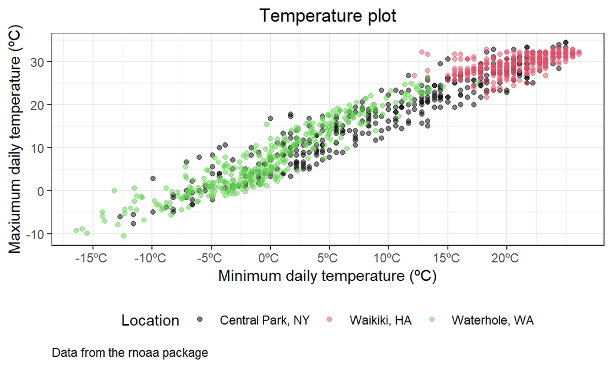

```r
weather_df %>%
  ggplot(aes(x = tmin, y = tmax)) +
  geom_point(aes(color = name), alpha = .5) +
  labs(
    title = "Temperature plot",
    x = "Minimum daily temperature (ºC)",
    y = "Maxiumum daily temperature (ºC)",
    caption = "Data from the rnoaa package",
    color = "Park") +
  scale_x_continuous(
    breaks = seq(-15, 20, 5),
    labels = paste0(seq(-15, 20, 5), "ºC", sep = " ")) +
  #scale_fill_discrete(name = "Location", labels = c("Central Park, NY", "Waikiki, HA", "Waterhole, WA"), aesthetics = "color") +
  scale_color_manual(values = c(1,2,3), name = "Location", labels = c("Central Park, NY", "Waikiki, HA", "Waterhole, WA"))
```

```r
  #scale_color_discrete(name = "Location", labels = c("Central Park, NY", "Waikiki, HA", "Waterhole, WA"))
```

- You can use `seq` to generate a sequence of numbers as ticks
- Use `scale_fill_discrete` to manually change the text in the legend. Using either `labs` or `scale_fill_discrete` (with the `aesthestics` argument) to change the title of the legend.

## Getting Started

1. Create a new R project and named it `Week 5 DS Recitation`
2. Put the `week_5_DS_recitation_1_data_viz.Rmd` file into the same folder of the R project you just created.

## Visualization

We are going to use NY NOAA data. Please load the data from the `p8105.datasets` package using:

```r
if (!requireNamespace("p8105.datasets", quietly = TRUE)) {
  devtools::install_github("p8105/p8105.datasets")
}

library(p8105.datasets)
data("ny_noaa")
```

Here, I did some basic cleaning for you:

```r
noaa_df = ny_noaa %>%
  separate(date, into = c("year","month","day"),sep = "-") %>%
  mutate(
    year = as.factor(year),
    month = as.integer(month),
    month = (month.name[month]),
    day = as.factor(day),
    prcp = prcp / 10,
    tmax = as.numeric(tmax),
    tmin = as.numeric(tmin),
    tmax = tmax / 10,
    tmin = tmin / 10
  )

# Here is a table shows the most common observations of snowfall
noaa_df %>%
  count(snow, name = "n_of_observations") %>%
  drop_na(snow) %>%
  arrange(desc(n_of_observations)) %>%
  head(n = 5)
```

```
## # A tibble: 5 × 2
##    snow n_of_observations
##   <int>             <int>
## 1     0           2008508
## 2    25             31022
## 3    13             23095
## 4    51             18274
## 5    76             10173
```

### Tasks:

Please complete the following tasks in groups of two or three:

1. Make a two-panel plot showing the average max temperature in January and in July in each station across years. Is there any observable / interpretable structure? Any outliers?

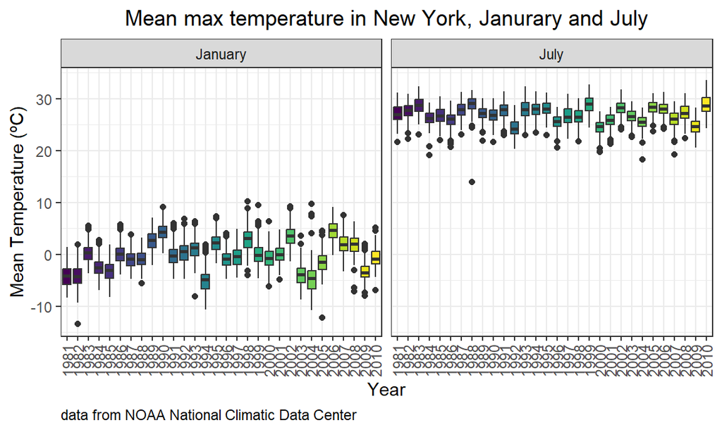

```r
# You may start with this processed data
noaa_df %>%
  #focus on Jan and Jul
  filter(month %in% c("January", "July")) %>%
  group_by(year, month, id) %>%
  summarise(mean_of_tmax = mean(tmax,na.rm = TRUE)) %>%
  ggplot(aes(x = year ,y = mean_of_tmax)) +
  geom_boxplot(aes(fill = year)) +
  facet_grid(.~month) +
  labs(
    title = "Mean max temperature in New York, Janurary and July",
    x = "Year",
    y = "Mean Temperature (ºC)",
    caption = "data from NOAA National Climatic Data Center"
  ) +
  theme(legend.position = "none")+
  theme(axis.text.x = element_text(angle = 90, vjust = 0.5, hjust = 1))
```

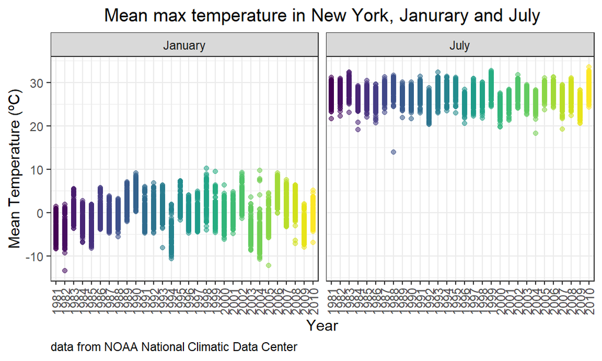

```r
# You may start with this processed data
noaa_df %>%
  #focus on Jan and Jul
  filter(month %in% c("January", "July")) %>%
  group_by(year, month, id) %>%
  summarise(mean_of_tmax = mean(tmax,na.rm = TRUE)) %>%
  ggplot(aes(x = year ,y = mean_of_tmax, color = year)) +
  geom_point(aes(color = year, alpha = 0.5)) +
  geom_smooth(method = "lm", alpha = 0.5) +
  facet_grid(.~month) +
  labs(
    title = "Mean max temperature in New York, Janurary and July",
    x = "Year",
    y = "Mean Temperature (ºC)",
    caption = "data from NOAA National Climatic Data Center"
  ) +
  theme(legend.position = "none")+
  theme(axis.text.x = element_text(angle = 90, vjust = 0.5, hjust = 1))
```

2. Make a two-panel plot showing (i) `tmax` vs `tmin` for the full dataset (note that a scatterplot may not be the best option); and (ii) make a plot showing the distribution of snowfall values greater than 0 and less than 100 separately by year.

Discuss with your group members to come up with the best way to visualize data.

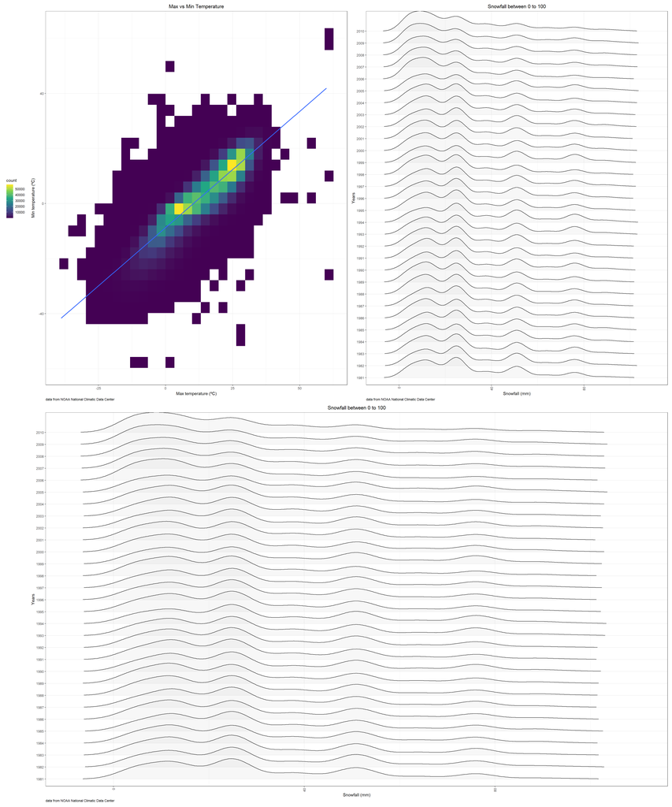

```r
library(ggridges)
library(patchwork)
tmax_tmin =
  noaa_df %>%
  ggplot(aes(x = tmax, y = tmin)) +
  geom_bin2d() +
  geom_smooth(method = "lm") +
    labs(
    title = "Max vs Min Temperature",
    x = "Max temperature (ºC)",
    y = "Min temperature (ºC)",
    caption = "data from NOAA National Climatic Data Center"
  ) +
  theme(legend.position = "left")

snow_fall =
  noaa_df %>%
  filter(between(snow,1,100), !is.na(snow)) %>%
  # between(x, left, right) is same as x >= left & x <= right
  ggplot(aes(x = snow)) +
  # you need to load ggridges first to use geom_density_ridges
  geom_density_ridges(aes(y = year,
                          group = as.factor(year)),
                          alpha = 0.1,
                      rel_min_height = 0.01) +
    labs(
    title = "Snowfall between 0 to 100",
    x = "Snowfall (mm)",
    y = "Years",
    caption = "data from NOAA National Climatic Data Center"
  ) +
  theme(legend.position = "none") +
  theme(axis.text.x = element_text(angle = 90, vjust = 0.5, hjust = 1))


(tmax_tmin + snow_fall) / snow_fall
```